# meteorologia

Lucía Martinez Maragreto

```r
library(sf)
library(arrow)
library(dplyr)
library(tidyr)
library(lubridate)
library(corrplot)
library(ggplot2)
library(openair)
```

Es carreguen les capes d’estacions meteorològiques, dades meteorològiques diàries i registres d’incendis forestals.

```r
est <- st_read("dades/processades/estacions_utm31n.gpkg")
meteo <- read_parquet("dades/processades/meteorologia.parquet")
inc <- st_read("dades/processades/incendis_2000_2024.gpkg")
```

S’obtenen els punts centrals dels polígons d’incendi per facilitar la relació espacial amb les estacions.

```r
inc_centroid <- st_centroid(inc)
```

S’identifica l’estació meteorològica activa més propera a cada incendi segons la data d’ocurrència.

```r
inc_centroid$ID_EST <- NA_character_

dates_incendi <- sort(unique(inc_centroid$DATA_INCEN))

for (d in dates_incendi) {

  idx_inc <- which(inc_centroid$DATA_INCEN == d)
  inc_d   <- inc_centroid[idx_inc, ]

  est_d <- est %>%
    filter(DATA_ALTA <= d,
      is.na(DATA_BAIXA) | DATA_BAIXA >= d)

  if (nrow(est_d) == 0) next

  idx_est <- st_nearest_feature(inc_d, est_d)

  inc_centroid$ID_EST[idx_inc] <- est_d$CODI_ESTACIO[idx_est]
}
```

Les dades es transformen a format ample per disposar d’una columna per cada variable meteorològica.

```r
meteo_wide <- meteo %>%
  select(CODI_ESTACIO, DATA_LECTURA, CODI_VARIABLE, VALOR) %>%
  distinct() %>%
  pivot_wider(
    names_from = CODI_VARIABLE,
    values_from = VALOR
  )
```

S’uneixen els incendis amb les mesures meteorològiques corresponents al dia i a l’estació assignada.

```r
inc_meteo_sf <- inc_centroid %>%
  left_join(
    meteo_wide,
    by = c("ID_EST" = "CODI_ESTACIO", "DATA_INCEN" = "DATA_LECTURA")
  ) %>%
  mutate(INCENDI = 1) %>%
  rename(DATA = DATA_INCEN) %>%
  select(-CODI_FINAL, -MUNICIPI, -ID_EST)

inc_meteo <- inc_meteo_sf %>% st_drop_geometry()
```

S’obté l’àrea de Catalunya excloent les zones afectades per incendis per simular condicions sense incendi.

```r
lim_cat <- st_read("dades/crues/divisions_admin/catalunya.gpkg")
st_crs(lim_cat) <- 25831

inc_union <- st_union(inc)
cat_sense_incendis <- st_difference(lim_cat, inc_union)
```

S’extreu un conjunt de punts aleatoris dins les zones sense incendi per representar dies sense incidència.

```r
n_no_incendis <- nrow(inc_meteo) * 3

set.seed(05052024)
punts_aleatoris <- st_sample(
  cat_sense_incendis,
  size = n_no_incendis,
  type = "random"
) %>%
  st_sf() %>%
  st_set_crs(25831)
```

S’assigna una data aleatòria dins del període d’estudi a cada punt del conjunt aleatori.

```r
dates_possibles <- seq(as.Date("2000-01-01"), as.Date("2024-12-31"), by = "day")
set.seed(05052024)
punts_aleatoris$DATA <- sample(dates_possibles, size = n_no_incendis, replace = TRUE)
```

S’identifica l’estació meteorològica activa més propera a cada punt segons la data assignada.

```r
punts_aleatoris$ID_EST <- NA_character_

dates_punts <- sort(unique(punts_aleatoris$DATA))

for (d in dates_punts) {

  idx_p <- which(punts_aleatoris$DATA == d)
  punts_d <- punts_aleatoris[idx_p, ]

  est_d <- est %>%
    filter(DATA_ALTA <= d & DATA_BAIXA >= d)

  if (nrow(est_d) == 0) next

  idx_est <- st_nearest_feature(punts_d, est_d)

  punts_aleatoris$ID_EST[idx_p] <- est_d$CODI_ESTACIO[idx_est]
}
```

Es determina la temporada de l’any associada a cada data.

```r
estacio_any <- function(date) {
  md <- month(date)*100 + day(date)
  case_when(
    between(md, 321, 620) ~ "Primavera",
    between(md, 621, 922) ~ "Estiu",
    between(md, 923, 1220) ~ "Tardor",
    TRUE ~ "Hivern"
  )
}
```

S’associen les dades meteorològiques als punts sense incendi i s’afegeixen variables temporals.

```r
no_inc_meteo_sf <- punts_aleatoris %>%
  left_join(
    meteo_wide,
    by = c("ID_EST" = "CODI_ESTACIO", "DATA" = "DATA_LECTURA")
  ) %>%
  mutate(
    INCENDI = 0,
    DIA = day(DATA),
    MES = month(DATA),
    ANY = year(DATA),
    DIA_SETMANA = factor(
      wday(DATA, week_start = 1),
      levels = 1:7,
      labels = c("dilluns", "dimarts", "dimecres", "dijous",
                 "divendres", "dissabte", "diumenge")
      ),
    TEMPORADA = estacio_any(DATA),
    HA_CREMADES = 0
  ) %>%
  rename(geom = geometry) %>%
  select(-ID_EST)

no_inc_meteo <- no_inc_meteo_sf %>% st_drop_geometry()
```

S’integren les observacions amb incendi i sense en un únic conjunt de dades per a l’anàlisi conjunta.

```r
dataset_final <- bind_rows(inc_meteo, no_inc_meteo)
```

Es crea una versió espacial per a possibles anàlisis geogràfiques.

```r
sf_final <- bind_rows(inc_meteo_sf, no_inc_meteo_sf)
```

S’analitza la relació mensual entre el nombre d’incendis i la temperatura màxima mitjana.

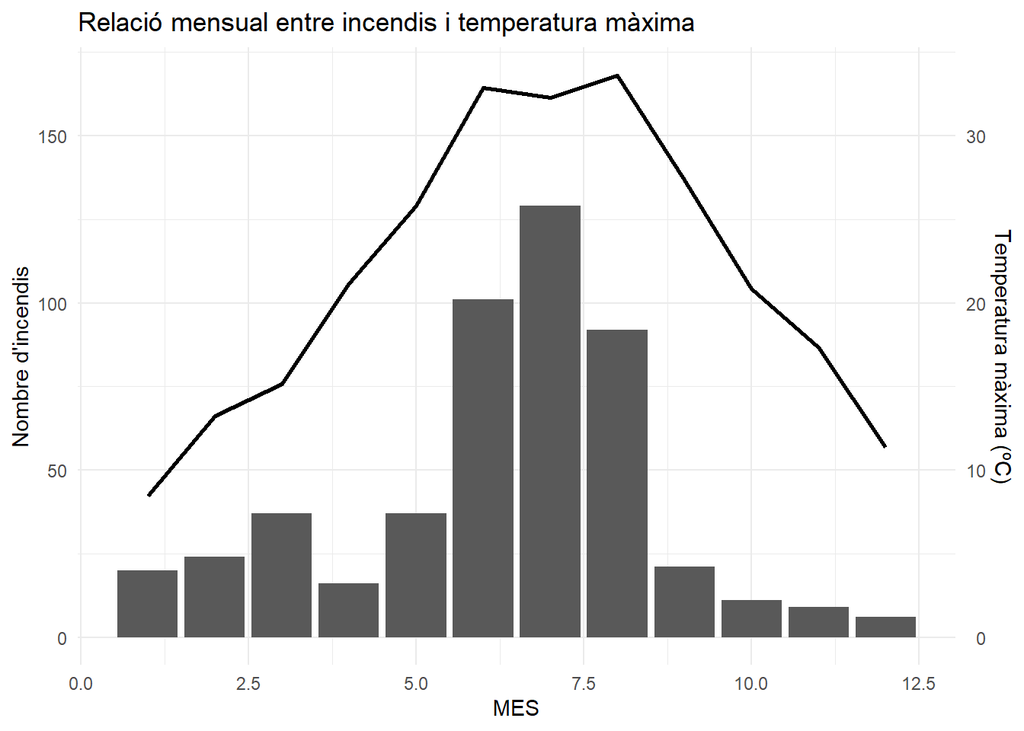

```r
inc_mes <- inc_meteo %>%
  group_by(MES) %>%
  summarise(
    n_incendis = n(),
    temp_max_mitjana = mean(`1001`, na.rm = TRUE)
  )

ggplot(inc_mes, aes(x = MES)) +
  geom_col(aes(y = n_incendis)) +
  geom_line(aes(y = temp_max_mitjana * 5), linewidth = 1) +
  scale_y_continuous(
    name = "Nombre d'incendis",
    sec.axis = sec_axis(~./5, name = "Temperatura màxima (ºC)")
  ) +
  labs(
    title = "Relació mensual entre incendis i temperatura màxima"
  ) +
  theme_minimal()
```

Se seleccionen les variables meteorològiques d’interès i es converteixen a format numèric.

```r
vars_meteo <- c("1001", "1102", "1300", "1400", "1503", "1512", "1515", "1700")
meteo_data <- dataset_final %>%
  select(all_of(vars_meteo)) %>%
  mutate(across(everything(), as.numeric))
```

Es calcula la matriu de correlacions utilitzant observacions completes per parelles.

```r
matriu_cor <- cor(meteo_data, use = "pairwise.complete.obs")
print(matriu_cor)
```

```
##             1001       1102        1300         1400        1503        1512
## 1001  1.00000000 -0.4699852 -0.15169653  0.666816608  0.08929694  0.12884351
## 1102 -0.46998518  1.0000000  0.33438122 -0.579273734 -0.27955151 -0.35851306
## 1300 -0.15169653  0.3343812  1.00000000 -0.246985697 -0.09527274 -0.04330379
## 1400  0.66681661 -0.5792737 -0.24698570  1.000000000  0.17278266  0.16560724
## 1503  0.08929694 -0.2795515 -0.09527274  0.172782662  1.00000000  0.87688281
## 1512  0.12884351 -0.3585131 -0.04330379  0.165607236  0.87688281  1.00000000
## 1515 -0.02353580 -0.1139026 -0.05310398 -0.003339809  0.20466809  0.18121198
## 1700  0.85023680 -0.5866900 -0.21353733  0.924265127  0.22292875  0.19254944
##              1515        1700
## 1001 -0.023535800  0.85023680
## 1102 -0.113902606 -0.58668998
## 1300 -0.053103984 -0.21353733
## 1400 -0.003339809  0.92426513
## 1503  0.204668090  0.22292875
## 1512  0.181211984  0.19254944
## 1515  1.000000000 -0.03052647
## 1700 -0.030526467  1.00000000
```

Es representa gràficament la matriu de correlacions mitjançant diagrames el·líptics.

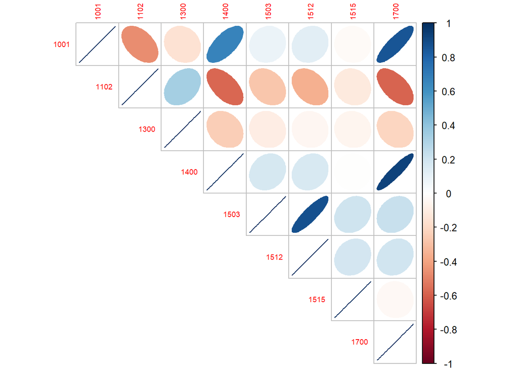

```r
corrplot(matriu_cor, method = "ellipse", type = "upper", tl.cex = 0.6, number.cex = 0.6)
```

Es calculen i es visualitzen les correlacions en dies amb incendi i en dies sense incendi.

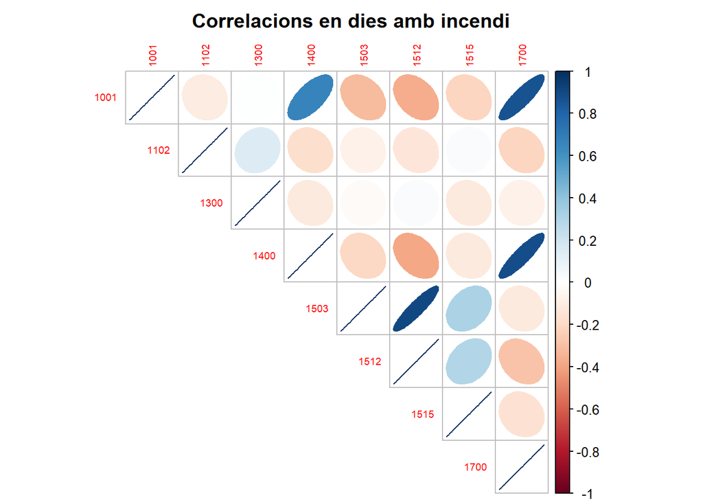

```r
cor_inc <- dataset_final %>%
  filter(INCENDI == 1) %>%
  select(all_of(vars_meteo)) %>%
  cor(use = "pairwise.complete.obs")

corrplot(cor_inc, title = "Correlacions en dies amb incendi", mar = c(0,0,2,0), method = "ellipse", type = "upper", tl.cex = 0.6, number.cex = 0.6)
```

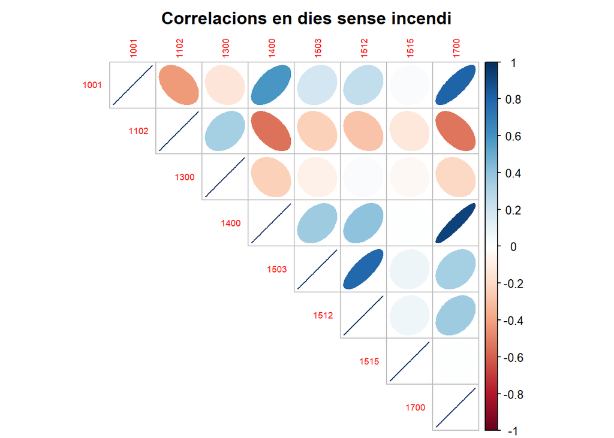

```r
cor_no_inc <- dataset_final %>%
  filter(INCENDI == 0) %>%
  select(all_of(vars_meteo)) %>%
  cor(use = "pairwise.complete.obs")

corrplot(cor_no_inc, title = "Correlacions en dies sense incendi", mar = c(0,0,2,0), method = "ellipse", type = "upper", tl.cex = 0.6, number.cex = 0.6)
```

S’obtenen les mitjanes de les variables meteorològiques agrupades segons la presència d’incendi.

```r
dataset_final %>%
  group_by(INCENDI) %>%
  summarise(
    temp_max = mean(`1001`, na.rm = TRUE),
    hum_min = mean(`1102`, na.rm = TRUE),
    prec = mean(`1300`, na.rm = TRUE),
    irradiacio = mean(`1400`, na.rm = TRUE),
    vent = mean(`1503`, na.rm = TRUE),
    ratxa = mean(`1512`, na.rm = TRUE),
    evapo = mean(`1700`, na.rm = TRUE)
  )
```

```
## # A tibble: 2 × 8
##   INCENDI temp_max hum_min  prec irradiacio  vent ratxa evapo
##     <dbl>    <dbl>   <dbl> <dbl>      <dbl> <dbl> <dbl> <dbl>
## 1       0     19.0    44.3 1.62        16.0  1.67  8.40  2.64
## 2       1     27.6    26.2 0.270       23.7  3.82 13.2   4.94
```

Es representa la distribució de la temperatura màxima en dies amb incendi.

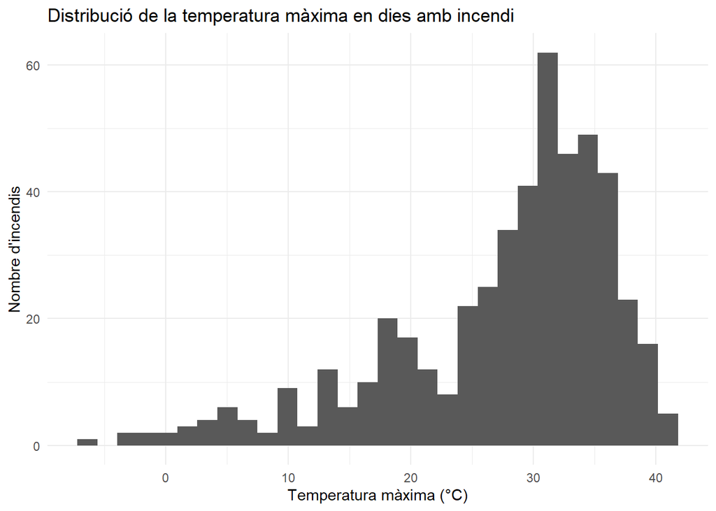

```r
ggplot(
  dataset_final %>% filter(INCENDI == 1),
  aes(x = `1001`)
) +
  geom_histogram(bins = 30) +
  labs(
    x = "Temperatura màxima (°C)",
    y = "Nombre d'incendis",
    title = "Distribució de la temperatura màxima en dies amb incendi"
  ) +
  theme_minimal()
```

Es compara la distribució de la temperatura màxima entre dies amb incendi i sense.

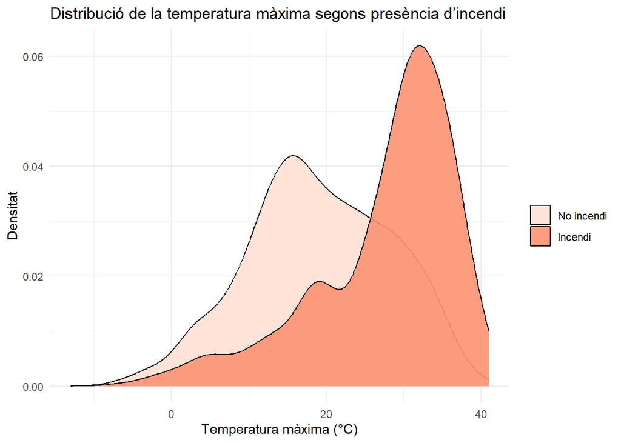

```r
ggplot(dataset_final, aes(x = `1001`, fill = factor(INCENDI))) +
  geom_density(alpha = 0.9) +
  scale_fill_brewer(
    palette = "Reds",
    direction = 1,
    labels = c("No incendi", "Incendi")
  ) +
  labs(
    x = "Temperatura màxima (°C)",
    y = "Densitat",
    fill = "",
    title = "Distribució de la temperatura màxima segons presència d’incendi"
  ) +
  theme_minimal()
```

S’avaluen les diferències de temperatura màxima entre dies amb incendi i sense.

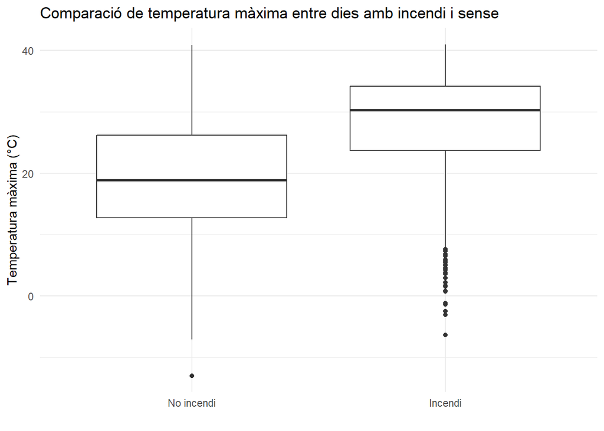

```r
ggplot(dataset_final, aes(x = factor(INCENDI), y = `1001`)) +
  geom_boxplot() +
  scale_x_discrete(labels = c("No incendi", "Incendi")) +
  labs(
    x = "",
    y = "Temperatura màxima (°C)",
    title = "Comparació de temperatura màxima entre dies amb incendi i sense"
  ) +
  theme_minimal()
```

S’estudia la variació de la temperatura màxima per temporada i presència d’incendi.

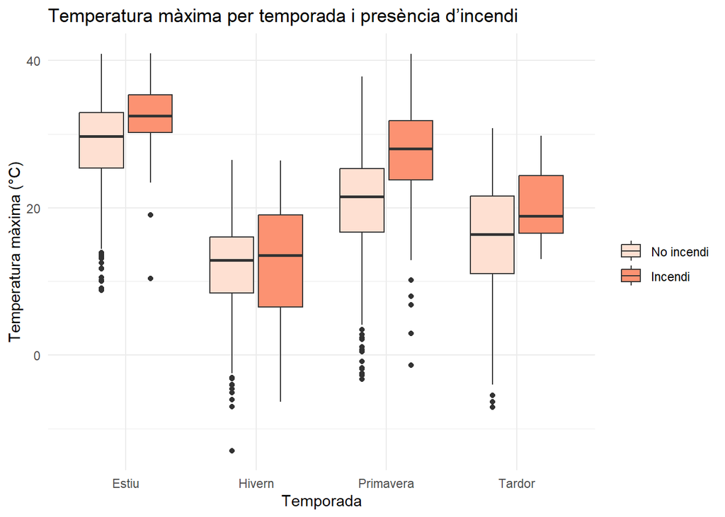

```r
ggplot(dataset_final, aes(x = TEMPORADA, y = `1001`, fill = factor(INCENDI))) +
  geom_boxplot() +
  scale_fill_brewer(
    palette = "Reds",
    direction = 1,
    labels = c("No incendi", "Incendi")
  ) +
  labs(
    x = "Temporada",
    y = "Temperatura màxima (°C)",
    fill = "",
    title = "Temperatura màxima per temporada i presència d’incendi"
  ) +
  theme_minimal()
```

S’examinen les diferències de precipitació acumulada entre dies amb incendi i sense.

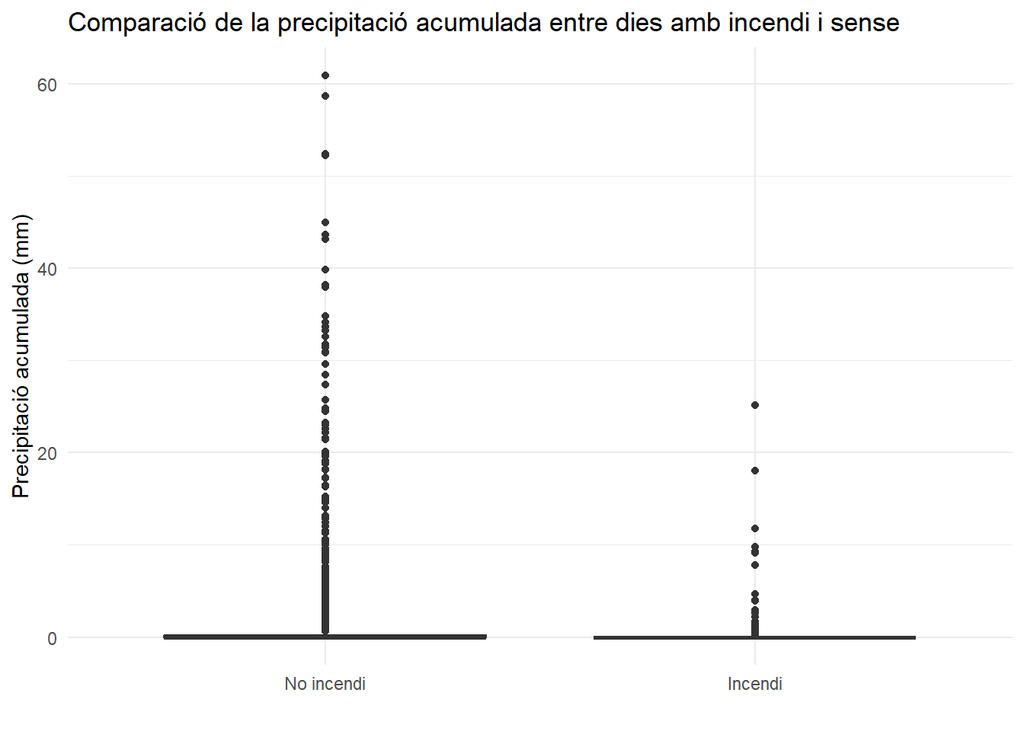

```r
ggplot(dataset_final, aes(x = factor(INCENDI), y = `1300`)) +
  geom_boxplot() +
  scale_x_discrete(labels = c("No incendi", "Incendi")) +
  labs(
    x = "",
    y = "Precipitació acumulada (mm)",
    title = "Comparació de la precipitació acumulada entre dies amb incendi i sense"
  ) +
  theme_minimal()
```

Es calcula el percentatge de dies sense precipitació segons la presència d’incendi.

```r
dataset_final %>%
  mutate(sec = `1300` == 0) %>%
  group_by(INCENDI) %>%
  summarise(percent_sec = mean(sec, na.rm = TRUE) * 100)
```

```
## # A tibble: 2 × 2
##   INCENDI percent_sec
##     <dbl>       <dbl>
## 1       0        70.3
## 2       1        91.7
```

Es compara la precipitació acumulada en dies amb pluja segons la presència d’incendi.

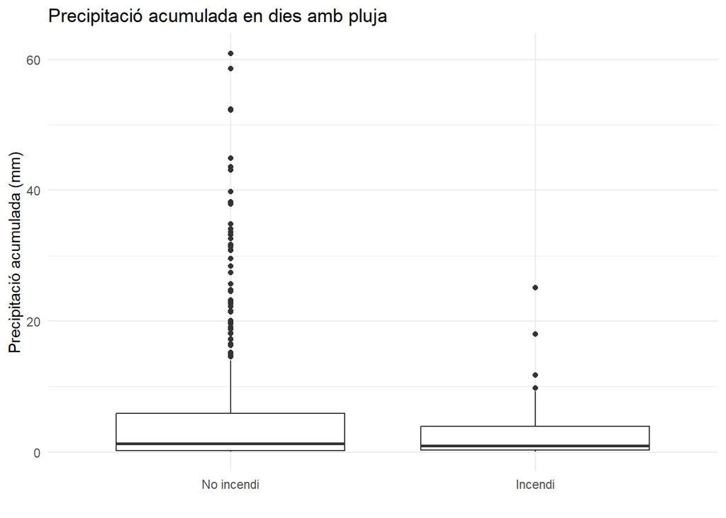

```r
ggplot(
  dataset_final %>% filter(`1300` > 0),
  aes(x = factor(INCENDI), y = `1300`)
) +
  geom_boxplot() +
  scale_x_discrete(labels = c("No incendi", "Incendi")) +
  labs(
    x = "",
    y = "Precipitació acumulada (mm)",
    title = "Precipitació acumulada en dies amb pluja"
  ) +
  theme_minimal()
```

S’examinen les diferències en humitat, irradiació, vent i evapotranspiració entre dies amb incendi i sense.

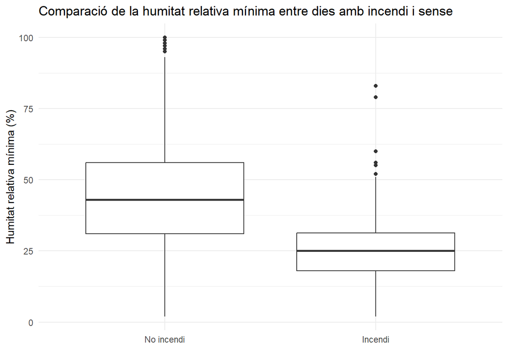

```r
ggplot(dataset_final, aes(x = factor(INCENDI), y = `1102`)) +
  geom_boxplot() +
  scale_x_discrete(labels = c("No incendi", "Incendi")) +
  labs(
    x = "",
    y = "Humitat relativa mínima (%)",
    title = "Comparació de la humitat relativa mínima entre dies amb incendi i sense"
  ) +
  theme_minimal()
```

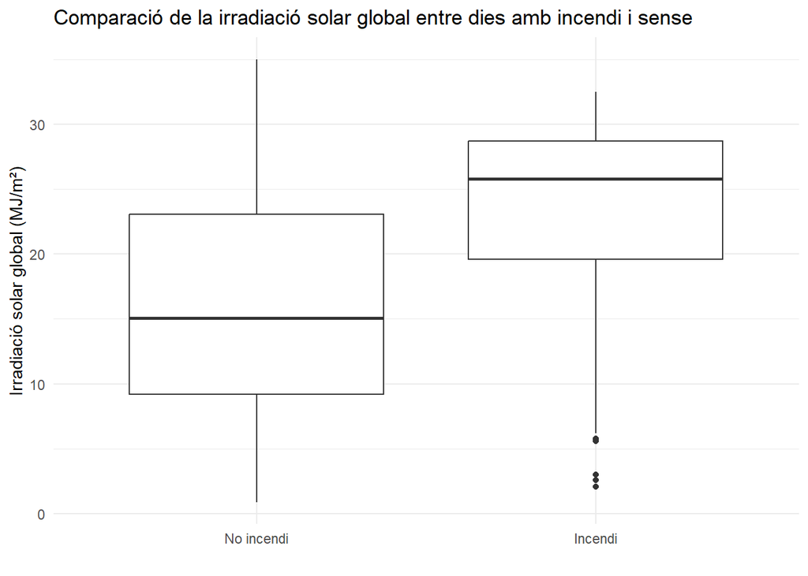

```r
ggplot(dataset_final, aes(x = factor(INCENDI), y = `1400`)) +
  geom_boxplot() +
  scale_x_discrete(labels = c("No incendi", "Incendi")) +
  labs(
    x = "",
    y = "Irradiació solar global (MJ/m²)",
    title = "Comparació de la irradiació solar global entre dies amb incendi i sense"
  ) +
  theme_minimal()
```

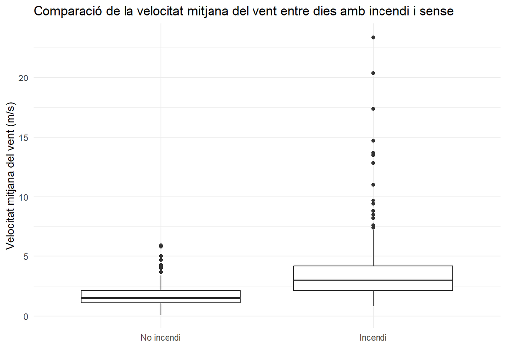

```r
ggplot(dataset_final, aes(x = factor(INCENDI), y = `1503`)) +
  geom_boxplot() +
  scale_x_discrete(labels = c("No incendi", "Incendi")) +
  labs(
    x = "",
    y = "Velocitat mitjana del vent (m/s)",
    title = "Comparació de la velocitat mitjana del vent entre dies amb incendi i sense"
  ) +
  theme_minimal()
```

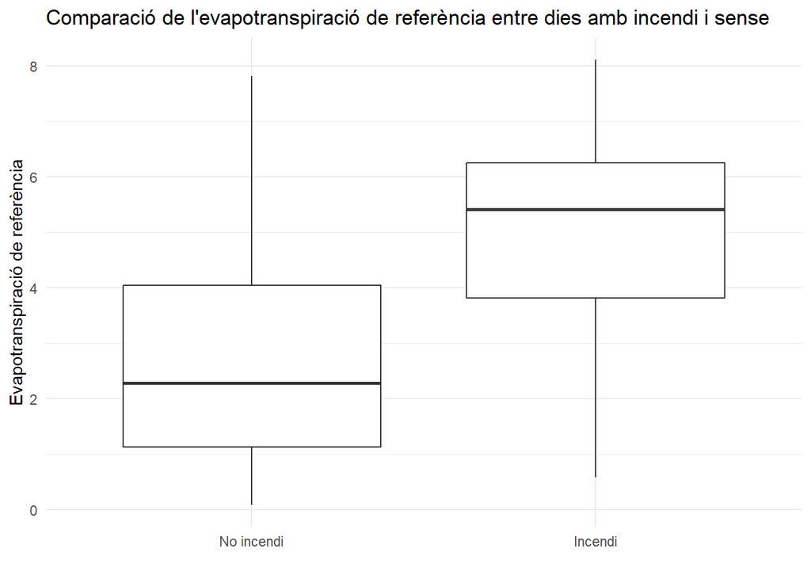

```r
ggplot(dataset_final, aes(x = factor(INCENDI), y = `1700`)) +
  geom_boxplot() +
  scale_x_discrete(labels = c("No incendi", "Incendi")) +
  labs(
    x = "",
    y = "Evapotranspiració de referència",
    title = "Comparació de l'evapotranspiració de referència entre dies amb incendi i sense"
  ) +
  theme_minimal()
```

Es classifica la direcció del vent en sectors cardinals.

```r
dataset_final <- dataset_final %>%
  mutate(
    dir_cat = cut(`1515`,
      breaks = c(-22.5, 22.5, 67.5, 112.5, 157.5, 202.5, 247.5, 292.5, 337.5, 382.5),
      labels = c("N","NE","E","SE","S","SW","W","NW","N"),
      include.lowest = TRUE
    )
  )
```

S’estudia la freqüència de les direccions del vent en dies amb incendi.

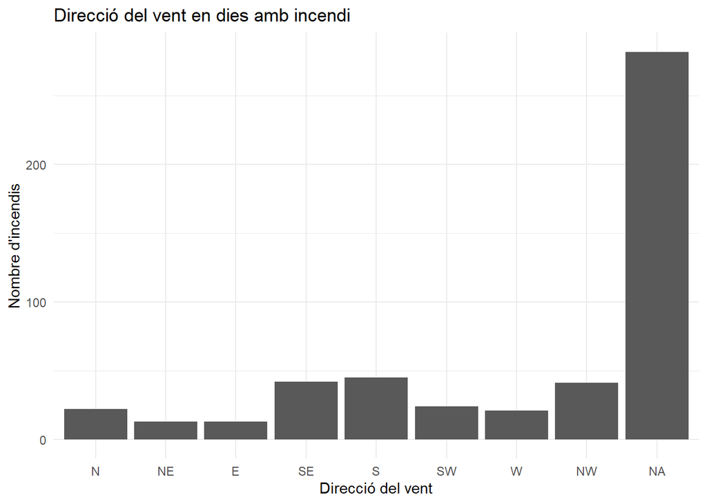

```r
dataset_final %>%
  filter(INCENDI == 1) %>%
  count(dir_cat) %>%
  ggplot(aes(x = dir_cat, y = n)) +
  geom_col() +
  labs(
    x = "Direcció del vent",
    y = "Nombre d'incendis",
    title = "Direcció del vent en dies amb incendi"
  ) +
  theme_minimal()
```

Es visualitza la distribució conjunta de la velocitat i direcció del vent segons la presència d’incendi.

```r
windRose(
  dataset_final,
  ws = "1503",  # velocitat
  wd = "1515",  # direcció
  type = "INCENDI",
  cols = c("steelblue", "firebrick")
)
```

[figure not shown]

Es compara la velocitat del vent segons la direcció i la presència d’incendi.

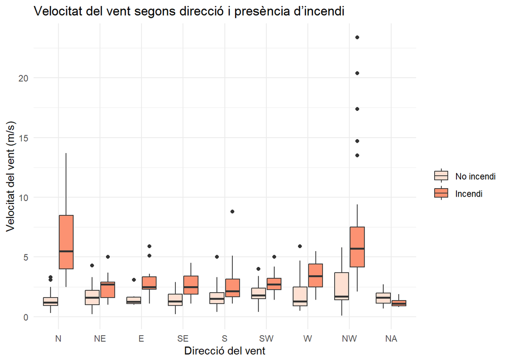

```r
ggplot(dataset_final, aes(x = dir_cat, y = `1503`, fill = factor(INCENDI))) +
  geom_boxplot() +
  scale_fill_brewer(
    palette = "Reds",
    direction = 1,
    labels = c("No incendi", "Incendi")
  ) +
  labs(
    x = "Direcció del vent",
    y = "Velocitat del vent (m/s)",
    fill = "",
    title = "Velocitat del vent segons direcció i presència d’incendi"
  ) +
  theme_minimal()
```

```r
st_write(sf_final, "dades/processades/sf_final.gpkg", delete_dsn = TRUE)
```

```
## Deleting source `dades/processades/sf_final.gpkg' using driver `GPKG'
## Writing layer `sf_final' to data source
##   `dades/processades/sf_final.gpkg' using driver `GPKG'
## Writing 2012 features with 16 fields and geometry type Point.
```